# NYC Air Quality

Minh Tran

11-14-2024

# New York City air quality surveillance report

2024-11-06

## Introduction

In our project, we analyze if air quality in New York City increased during last years. For these purposes, we use New York City air quality surveillance data (https://catalog.data.gov/dataset/air-quality). We investigate dynamics of 18 indexes of air quality. Some of them are considered separately for adults and children. Our dataset consists of 18,025 observations. One observation is value for some index for some period for some geo place. Respectively, values for all indexes that are presented on plots are averaged by geo places. In general, our data covers period 2005-2022 but for some indexes it is narrower.

## Data preparation

```r
#Libraries used:
library(readr)
library(ggplot2)
library(tidyverse)
```

```r
#Data loading:
data <- read_csv("Air_Quality.csv", show_col_types = FALSE)
glimpse(data)
```

```
## Rows: 18,025
## Columns: 12
## $ `Unique ID`      <dbl> 179772, 179785, 178540, 178561, 823217, 177910, 17795…
## $ `Indicator ID`   <dbl> 640, 640, 365, 365, 365, 365, 365, 365, 365, 365, 365…
## $ Name             <chr> "Boiler Emissions- Total SO2 Emissions", "Boiler Emis…
## $ Measure          <chr> "Number per km2", "Number per km2", "Mean", "Mean", "…
## $ `Measure Info`   <chr> "number", "number", "mcg/m3", "mcg/m3", "mcg/m3", "mc…
## $ `Geo Type Name`  <chr> "UHF42", "UHF42", "UHF42", "UHF42", "UHF42", "UHF42",…
## $ `Geo Join ID`    <dbl> 409, 209, 209, 409, 409, 209, 209, 409, 409, 410, 209…
## $ `Geo Place Name` <chr> "Southeast Queens", "Bensonhurst - Bay Ridge", "Benso…
## $ `Time Period`    <chr> "2015", "2015", "Annual Average 2012", "Annual Averag…
## $ Start_Date       <chr> "01/01/2015", "01/01/2015", "12/01/2011", "12/01/2011…
## $ `Data Value`     <dbl> 0.3, 1.2, 8.6, 8.0, 6.1, 10.0, 9.8, 9.8, 9.6, 7.2, 8.…
## $ Message          <lgl> NA, NA, NA, NA, NA, NA, NA, NA, NA, NA, NA, NA, NA, N…
```

```r
#Creation of subsets for every indicator:
data_1 <- data[data$Name == "Annual vehicle miles traveled",]
data_2 <- data[data$Name == "Annual vehicle miles traveled (trucks)",]
data_3_1 <- data[ (data$Name == "Asthma emergency departments visits due to Ozone") &
                   (data$Measure == "Estimated annual rate (age 18+)"),]
data_3_2 <- data[data$Name == "Asthma emergency departments visits due to Ozone" &
                  (data$Measure == "Estimated annual rate (under age 18)"),]
data_4 <- data[data$Name == "Boiler Emissions- Total NOx Emissions",]
data_5 <- data[data$Name == "Boiler Emissions- Total SO2 Emissions",]
data_6 <- data[data$Name == "Cardiovascular hospitalizations due to PM2.5 (age 40+)",]
data_7 <- data[data$Name == "Fine particles (PM 2.5)" & grepl("Annual Average", data$`Time Period`),]
data_8 <- data[data$Name == "Outdoor Air Toxics - Benzene",]
data_9 <- data[data$Name == "Ozone (O3)" & grepl("Summer 20", data$`Time Period`),]
data_10 <- data[data$Name == "Annual vehicle miles traveled (cars)",]
data_11_1 <- data[(data$Name == "Asthma emergency department visits due to PM2.5") &
                    (data$Measure == "Estimated annual rate (age 18+)"),]
data_11_2 <- data[data$Name == "Asthma emergency department visits due to PM2.5" &
                    (data$Measure == "Estimated annual rate (under age 18)"),]
data_12_1 <- data[data$Name == "Asthma hospitalizations due to Ozone" &
                  (data$Measure == "Estimated annual rate (age 18+)"),]
data_12_2 <- data[data$Name == "Asthma hospitalizations due to Ozone" &
                  (data$Measure == "Estimated annual rate (under age 18)"),]
data_13 <- data[data$Name == "Boiler Emissions- Total PM2.5 Emissions",]
data_14 <- data[data$Name == "Cardiac and respiratory deaths due to Ozone",]
data_15 <- data[data$Name == "Deaths due to PM2.5",]
data_16 <- data[data$Name == "Nitrogen dioxide (NO2)" & grepl("Annual Average", data$`Time Period`),]
data_17 <- data[data$Name == "Outdoor Air Toxics - Formaldehyde",]
data_18 <- data[data$Name == "Respiratory hospitalizations due to PM2.5 (age 20+)",]
```

```r
#Calculation of average values of indicators for every time period:
averaged_data_1 <- aggregate(data_1$`Data Value`, by = list(data_1$`Time Period`), FUN = mean)
averaged_data_2 <- aggregate(data_2$`Data Value`, by = list(data_2$`Time Period`), FUN = mean)
averaged_data_3_1 <- aggregate(data_3_1$`Data Value`, by = list(data_3_1$`Time Period`), FUN = mean)
averaged_data_3_2 <- aggregate(data_3_2$`Data Value`, by = list(data_3_2$`Time Period`), FUN = mean)
averaged_data_4 <- aggregate(data_4$`Data Value`, by = list(data_4$`Time Period`), FUN = mean)
averaged_data_5 <- aggregate(data_5$`Data Value`, by = list(data_5$`Time Period`), FUN = mean)
averaged_data_6 <- aggregate(data_6$`Data Value`, by = list(data_6$`Time Period`), FUN = mean)
averaged_data_7 <- aggregate(data_7$`Data Value`, by = list(data_7$`Time Period`), FUN = mean)
averaged_data_8 <- aggregate(data_8$`Data Value`, by = list(data_8$`Time Period`), FUN = mean)
averaged_data_9 <- aggregate(data_9$`Data Value`, by = list(data_9$`Time Period`), FUN = mean)
averaged_data_10 <- aggregate(data_10$`Data Value`, by = list(data_10$`Time Period`), FUN = mean)
averaged_data_11_1 <- aggregate(data_11_1$`Data Value`, by = list(data_11_1$`Time Period`), FUN = mean)
averaged_data_11_2 <- aggregate(data_11_2$`Data Value`, by = list(data_11_2$`Time Period`), FUN = mean)
averaged_data_12_1 <- aggregate(data_12_1$`Data Value`, by = list(data_12_1$`Time Period`), FUN = mean)
averaged_data_12_2 <- aggregate(data_12_2$`Data Value`, by = list(data_12_2$`Time Period`), FUN = mean)
averaged_data_13 <- aggregate(data_13$`Data Value`, by = list(data_13$`Time Period`), FUN = mean)
averaged_data_14 <- aggregate(data_14$`Data Value`, by = list(data_14$`Time Period`), FUN = mean)
averaged_data_15 <- aggregate(data_15$`Data Value`, by = list(data_15$`Time Period`), FUN = mean)
averaged_data_16 <- aggregate(data_16$`Data Value`, by = list(data_16$`Time Period`), FUN = mean)
averaged_data_17 <- aggregate(data_17$`Data Value`, by = list(data_17$`Time Period`), FUN = mean)
averaged_data_18 <- aggregate(data_18$`Data Value`, by = list(data_18$`Time Period`), FUN = mean)
```

```r
#Renaming columns for averaged dataframes:
colnames(averaged_data_1) <- c("Period", "Value")
colnames(averaged_data_2) <- c("Period", "Value")
colnames(averaged_data_3_1) <- c("Period", "Value")
colnames(averaged_data_3_2) <- c("Period", "Value")
colnames(averaged_data_4) <- c("Period", "Value")
colnames(averaged_data_5) <- c("Period", "Value")
colnames(averaged_data_6) <- c("Period", "Value")
colnames(averaged_data_7) <- c("Period", "Value")
colnames(averaged_data_8) <- c("Period", "Value")
colnames(averaged_data_9) <- c("Period", "Value")
colnames(averaged_data_10) <- c("Period", "Value")
colnames(averaged_data_11_1) <- c("Period", "Value")
colnames(averaged_data_11_2) <- c("Period", "Value")
colnames(averaged_data_12_1) <- c("Period", "Value")
colnames(averaged_data_12_2) <- c("Period", "Value")
colnames(averaged_data_13) <- c("Period", "Value")
colnames(averaged_data_14) <- c("Period", "Value")
colnames(averaged_data_15) <- c("Period", "Value")
colnames(averaged_data_16) <- c("Period", "Value")
colnames(averaged_data_17) <- c("Period", "Value")
colnames(averaged_data_18) <- c("Period", "Value")
```

## 1. Annual vehicle miles traveled

```r
#Table with values of indicator:
averaged_data_1
```

```
##   Period    Value
## 1   2005 67.17757
## 2   2010 73.14673
## 3   2019 79.96636
```

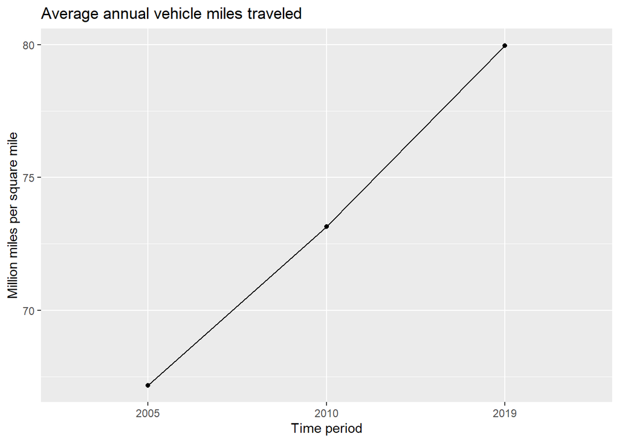

```r
#Linear plot for indicator by time:
ggplot(averaged_data_1, aes(x = Period, y = Value, group = 1)) +
  geom_point() +
  geom_line() +
  labs(title = "Average annual vehicle miles traveled",
       x = "Time period",
       y = "Million miles per square mile")
```

Average annual vehicle miles traveled grew from 67.17757 million miles per square mile in 2005 to 79.96636 million miles per square mile in 2019. It tells us about potential decrease of air quality.

## 2. Annual vehicle miles traveled (trucks)

```r
#Table with values of indicator:
averaged_data_2
```

```
##   Period    Value
## 1   2005 3.767290
## 2   2010 3.416822
## 3   2019 4.477570
```

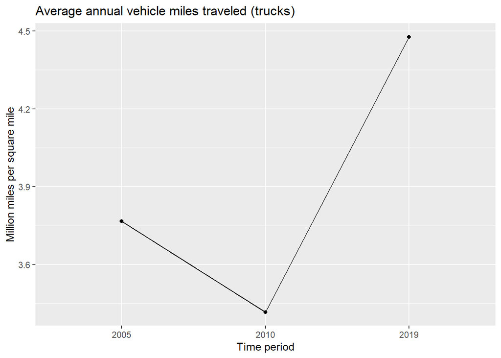

```r
#Linear plot for indicator by time:
ggplot(averaged_data_2, aes(x = Period, y = Value, group = 1)) +
  geom_point() +
  geom_line() +
  labs(title = "Average annual vehicle miles traveled (trucks)",
       x = "Time period",
       y = "Million miles per square mile")
```

Average annual vehicle miles traveled by trucks grew from 3.767290 million miles per square mile in 2005 to 4.477570 million miles per square mile in 2019. It tells us about potential decrease of air quality.

## 3.1. Asthma emergency departments visits due to Ozone, age 18+

```r
#Table with values of indicator:
averaged_data_3_1
```

```
##      Period    Value
## 1 2005-2007 48.41458
## 2 2009-2011 49.35625
## 3 2012-2014 55.87292
## 4 2015-2017 49.60000
## 5 2017-2019 41.33333
```

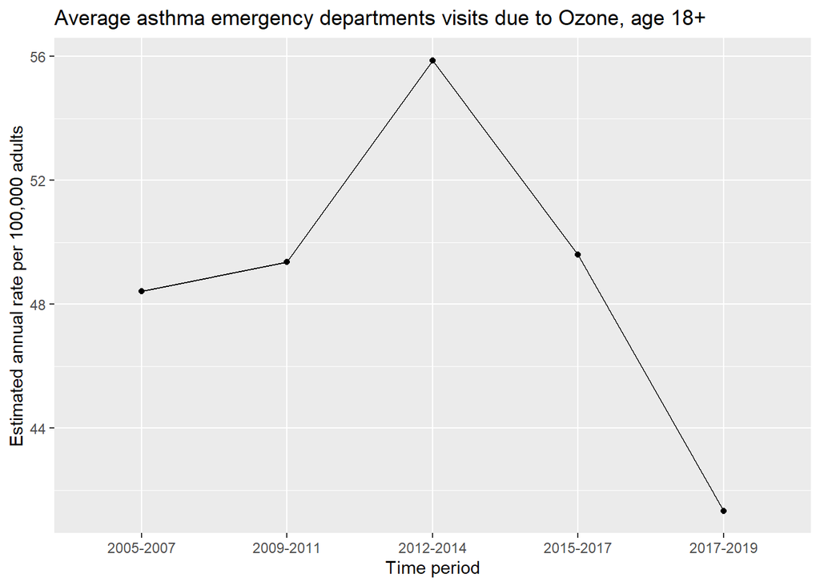

```r
#Linear plot for indicator by time:
ggplot(averaged_data_3_1, aes(x = Period, y = Value, group = 1)) +
  geom_point() +
  geom_line() +
  labs(title = "Average asthma emergency departments visits due to Ozone, age 18+",
       x = "Time period",
       y = "Estimated annual rate per 100,000 adults")
```

Average asthma emergency departments visits due to Ozone fell from 48.41458 per 100,000 adults in 2005-2007 to 41.33333 per 100,000 adults in 2017-2019. It tells us about potential increase of air quality.

## 3.2. Asthma emergency departments visits due to Ozone, under age 18

```r
#Table with values of indicator:
averaged_data_3_2
```

```
##      Period     Value
## 1 2005-2007  86.98958
## 2 2009-2011 103.18750
## 3 2012-2014 109.46042
## 4 2015-2017  94.86458
## 5 2017-2019  79.88679
```

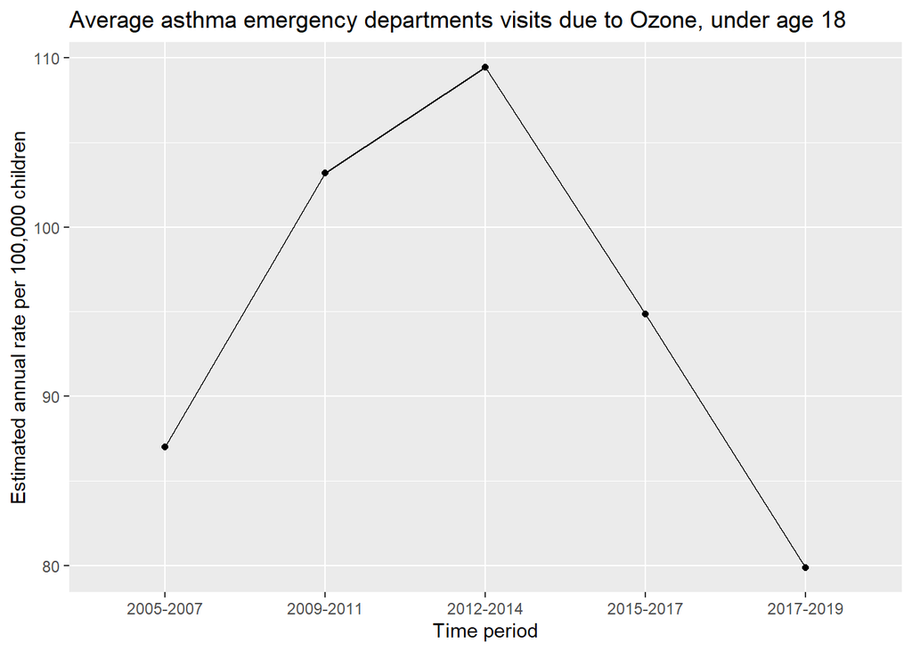

```r
#Linear plot for indicator by time:
ggplot(averaged_data_3_2, aes(x = Period, y = Value, group = 1)) +
  geom_point() +
  geom_line() +
  labs(title = "Average asthma emergency departments visits due to Ozone, under age 18",
       x = "Time period",
       y = "Estimated annual rate per 100,000 children")
```

Average asthma emergency departments visits due to Ozone fell from 86.98958 per 100,000 children in 2005-2007 to 79.88679 per 100,000 children in 2017-2019. It tells us about potential increase of air quality.

## 4. Boiler Emissions - Total NOx Emissions

```r
#Table with values of indicator:
averaged_data_4
```

```
##   Period    Value
## 1   2013 56.30000
## 2   2015 51.28333
```

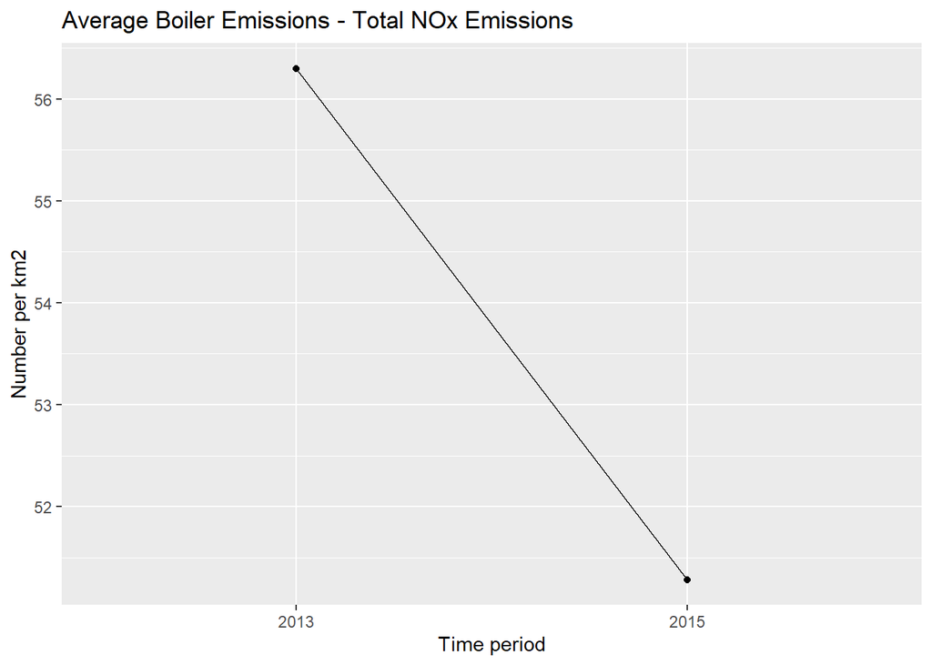

```r
#Linear plot for indicator by time:
ggplot(averaged_data_4, aes(x = Period, y = Value, group = 1)) +
  geom_point() +
  geom_line() +
  labs(title = "Average Boiler Emissions - Total NOx Emissions",
       x = "Time period",
       y = "Number per km2")
```

Average Boiler Emissions - Total NOx Emissions fell from 56.30000 per km2 in 2013 to 51.28333 per km2 in 2015. It tells us about potential increase of air quality.

## 5. Boiler Emissions- Total SO2 Emissions

```r
#Table with values of indicator:
averaged_data_5
```

```
##   Period     Value
## 1   2013 14.231250
## 2   2015  7.752083
```

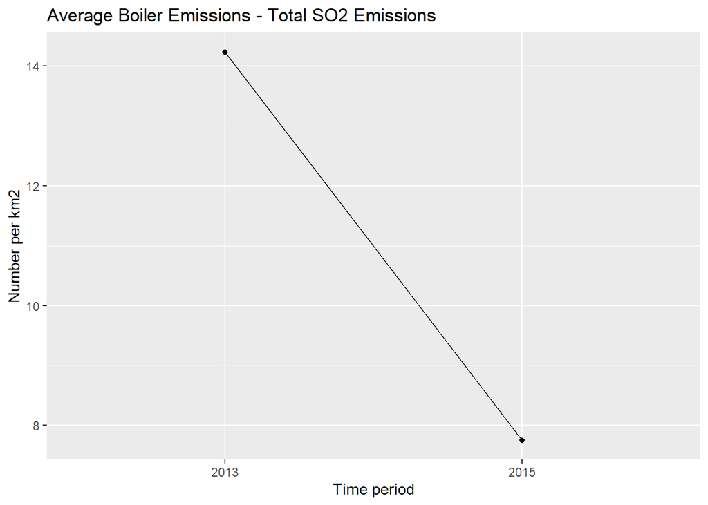

```r
#Linear plot for indicator by time:
ggplot(averaged_data_5, aes(x = Period, y = Value, group = 1)) +
  geom_point() +
  geom_line() +
  labs(title = "Average Boiler Emissions - Total SO2 Emissions",
       x = "Time period",
       y = "Number per km2")
```

Average Boiler Emissions - Total SO2 Emissions fell from 14.231250 per km2 in 2013 to 7.752083 per km2 in 2015. It tells us about potential increase of air quality.

## 6. Cardiovascular hospitalizations due to PM2.5, age 40+

```r
#Table with values of indicator:
averaged_data_6
```

```
##      Period     Value
## 1 2005-2007 26.150000
## 2 2009-2011 17.708333
## 3 2012-2014 13.372917
## 4 2015-2017 16.989583
## 5 2017-2019  9.645833
```

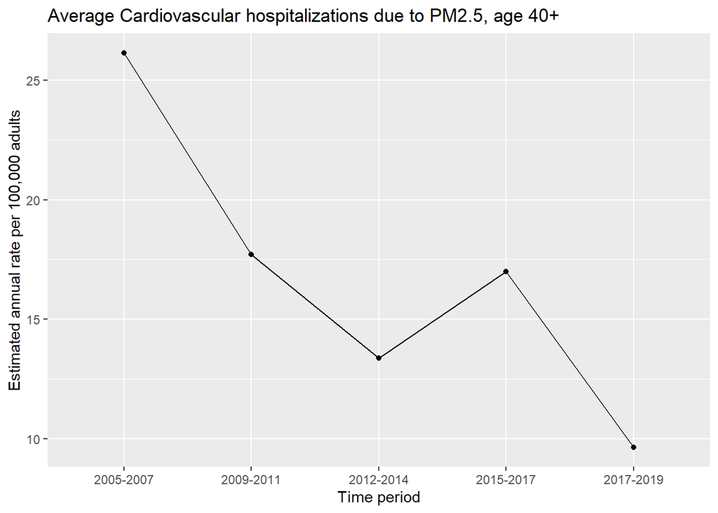

```r
#Linear plot for indicator by time:
ggplot(averaged_data_6, aes(x = Period, y = Value, group = 1)) +
  geom_point() +
  geom_line() +
  labs(title = "Average Cardiovascular hospitalizations due to PM2.5, age 40+",
       x = "Time period",
       y = "Estimated annual rate per 100,000 adults")
```

Average cardiovascular hospitalizations due to PM2.5 for people older than 40 years fell from 26.150000 per 100,000 adults in 2005-2007 to 9.645833 per 100,000 adults in 2017-2019. It tells us about potential increase of air quality.

## 7. Fine particles (PM 2.5)

```r
#Table with values of indicator:
averaged_data_7$Period <- gsub("Annual Average ", "", averaged_data_7$Period)
averaged_data_7
```

```
##    Period     Value
## 1    2009 10.986525
## 2    2010 10.074468
## 3    2011 10.587234
## 4    2012  9.445390
## 5    2013  9.141844
## 6    2014  9.407801
## 7    2015  9.043972
## 8    2016  7.894326
## 9    2017  7.741135
## 10   2018  7.395745
## 11   2019  7.015603
## 12   2020  6.326950
## 13   2021  6.760993
## 14   2022  6.067376
```

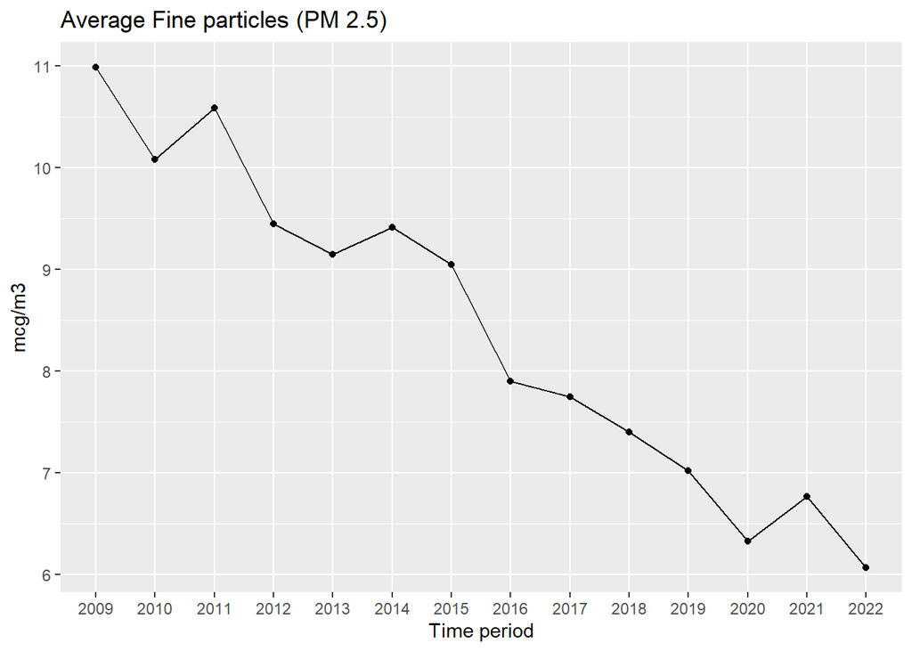

```r
#Linear plot for indicator by time:
ggplot(averaged_data_7, aes(x = Period, y = Value, group = 1)) +
  geom_point() +
  geom_line() +
  labs(title = "Average Fine particles (PM 2.5)",
       x = "Time period",
       y = "mcg/m3")
```

Average Fine particles (PM 2.5) fell from 10.986525 mcg/m3 in 2009 to 6.067376 mcg/m3 in 2022. It tells us about potential increase of air quality.

## 8. Outdoor Air Toxics - Benzene

```r
#Table with values of indicator:
averaged_data_8
```

```
##   Period    Value
## 1   2005 2.910417
## 2   2011 1.633645
## 3   2014 0.925000
```

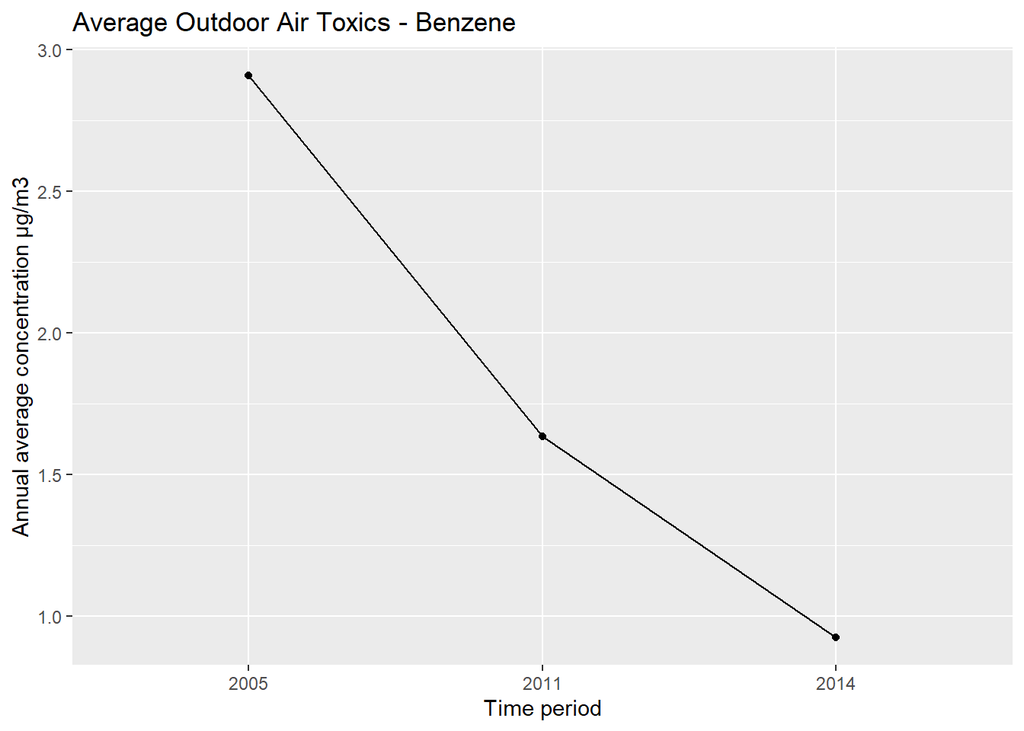

```r
#Linear plot for indicator by time:
ggplot(averaged_data_8, aes(x = Period, y = Value, group = 1)) +
  geom_point() +
  geom_line() +
  labs(title = "Average Outdoor Air Toxics - Benzene",
       x = "Time period",
       y = "Annual average concentration µg/m3")
```

Average Outdoor Air Toxics - Benzene fell from 2.910417 µg/m3 in 2005 to 0.925000 µg/m3 in 2014. It tells us about potential increase of air quality.

## 9. Ozone (O3)

```r
#Table with values of indicator:
averaged_data_9$Period <- gsub("Summer ", "", averaged_data_9$Period)
averaged_data_9
```

```
##    Period    Value
## 1    2009 24.76879
## 2    2010 32.44113
## 3    2011 31.81915
## 4    2012 32.92908
## 5    2013 30.03901
## 6    2014 30.45390
## 7    2015 30.91560
## 8    2016 32.98298
## 9    2017 28.79362
## 10   2018 29.92553
## 11   2019 29.64539
## 12   2020 29.73404
## 13   2021 29.73688
## 14   2022 33.15603
```

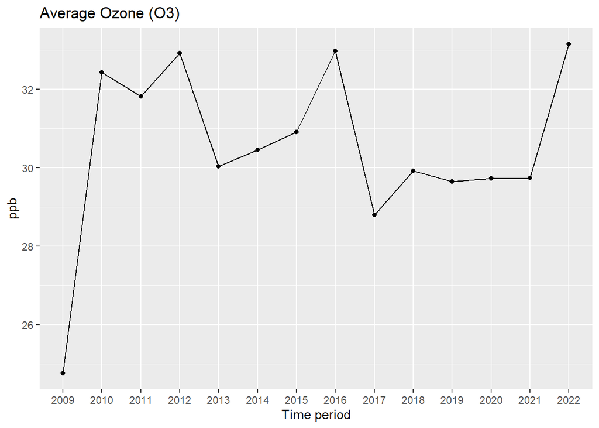

```r
#Linear plot for indicator by time:
ggplot(averaged_data_9, aes(x = Period, y = Value, group = 1)) +
  geom_point() +
  geom_line() +
  labs(title = "Average Ozone (O3)",
       x = "Time period",
       y = "ppb")
```

Average Ozone (O3) grew from 24.76879 ppb in 2009 to 33.15603 ppb in 2022. It tells us about potential decrease of air quality.

## 10. Annual vehicle miles traveled (cars)

```r
#Table with values of indicator:
averaged_data_10
```

```
##   Period    Value
## 1   2005 62.80374
## 2   2010 67.60654
## 3   2019 72.91121
```

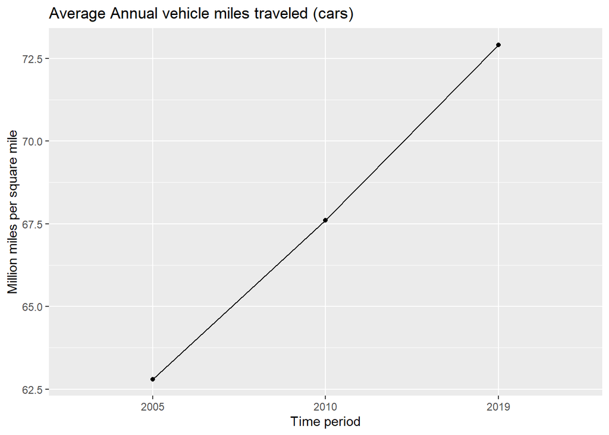

```r
#Linear plot for indicator by time:
ggplot(averaged_data_10, aes(x = Period, y = Value, group = 1)) +
  geom_point() +
  geom_line() +
  labs(title = "Average Annual vehicle miles traveled (cars)",
       x = "Time period",
       y = "Million miles per square mile")
```

Average annual vehicle miles traveled by cars grew from 62.80374 million miles per square mile in 2005 to 72.91121 million miles per square mile in 2019. It tells us about potential decrease of air quality.

## 11.1. Asthma emergency department visits due to PM2.5, age 18+

```r
#Table with values of indicator:
averaged_data_11_1
```

```
##      Period    Value
## 1 2005-2007 61.17917
## 2 2009-2011 46.74792
## 3 2012-2014 43.88958
## 4 2015-2017 35.51458
## 5 2017-2019 28.75000
```

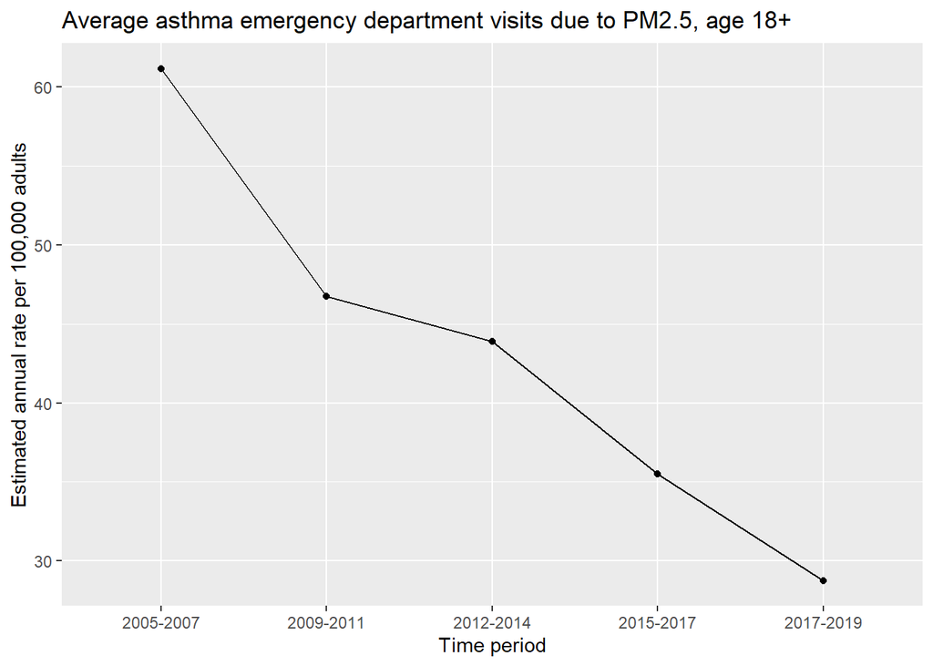

```r
#Linear plot for indicator by time:
ggplot(averaged_data_11_1, aes(x = Period, y = Value, group = 1)) +
  geom_point() +
  geom_line() +
  labs(title = "Average asthma emergency department visits due to PM2.5, age 18+",
       x = "Time period",
       y = "Estimated annual rate per 100,000 adults")
```

Average asthma emergency departments visits due to PM2.5 fell from 61.17917 per 100,000 adults in 2005-2007 to 28.75000 per 100,000 adults in 2017-2019. It tells us about potential increase of air quality.

## 11.2. Asthma emergency department visits due to PM2.5, under age 18

```r
#Table with values of indicator:
averaged_data_11_2
```

```
##      Period     Value
## 1 2005-2007 119.68542
## 2 2009-2011 100.21667
## 3 2012-2014  91.25417
## 4 2015-2017  72.85000
## 5 2017-2019  58.41667
```

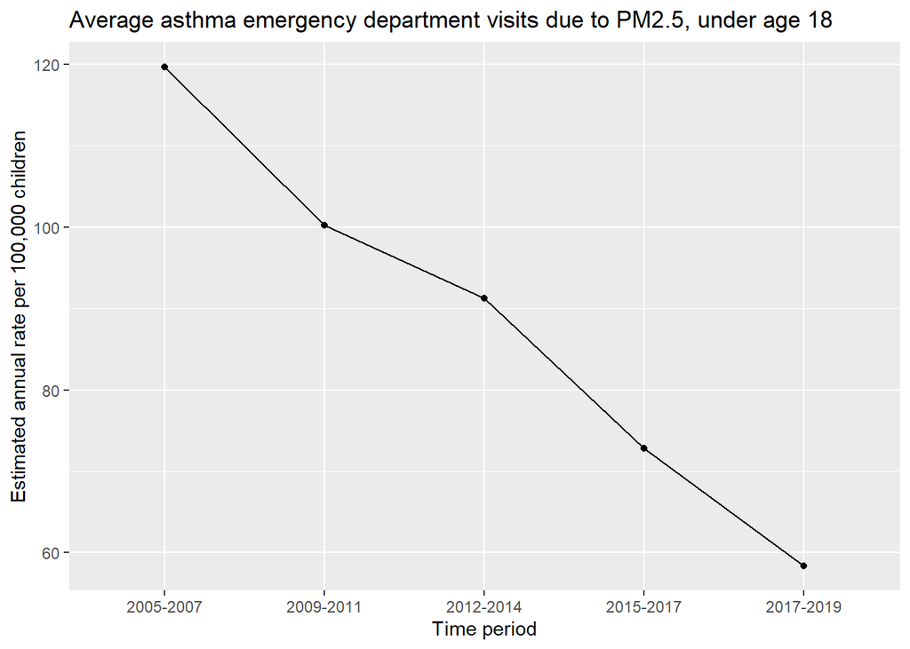

```r
#Linear plot for indicator by time:
ggplot(averaged_data_11_2, aes(x = Period, y = Value, group = 1)) +
  geom_point() +
  geom_line() +
  labs(title = "Average asthma emergency department visits due to PM2.5, under age 18",
       x = "Time period",
       y = "Estimated annual rate per 100,000 children")
```

Average asthma emergency departments visits due to PM2.5 fell from 119.68542 per 100,000 children in 2005-2007 to 58.41667 per 100,000 children in 2017-2019. It tells us about potential increase of air quality.

## 12.1. Asthma hospitalizations due to Ozone, age 18+

```r
#Table with values of indicator:
averaged_data_12_1
```

```
##      Period    Value
## 1 2005-2007 7.514583
## 2 2009-2011 7.252083
## 3 2012-2014 6.806250
## 4 2015-2017 4.070833
## 5 2017-2019 2.729167
```

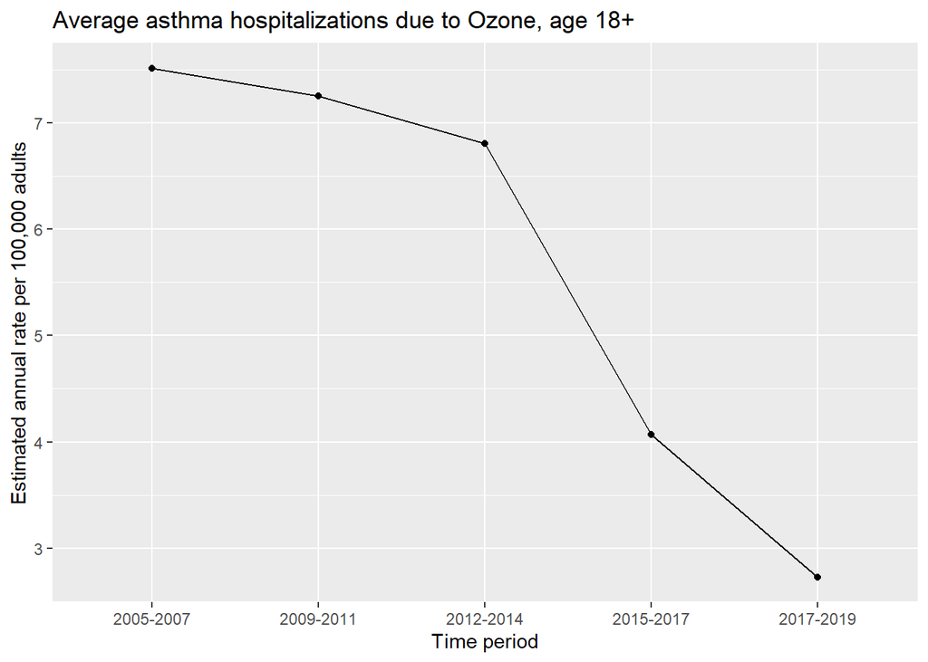

```r
#Linear plot for indicator by time:
ggplot(averaged_data_12_1, aes(x = Period, y = Value, group = 1)) +
  geom_point() +
  geom_line() +
  labs(title = "Average asthma hospitalizations due to Ozone, age 18+",
       x = "Time period",
       y = "Estimated annual rate per 100,000 adults")
```

Average asthma hospitalizations due to Ozone fell from 7.514583 per 100,000 adults in 2005-2007 to 2.729167 per 100,000 adults in 2017-2019. It tells us about potential increase of air quality.

## 12.2 Asthma hospitalizations due to Ozone, under age 18

```r
#Table with values of indicator:
averaged_data_12_2
```

```
##      Period    Value
## 1 2005-2007 19.53333
## 2 2009-2011 20.85208
## 3 2012-2014 21.81875
## 4 2015-2017 17.10833
## 5 2017-2019 14.50000
```

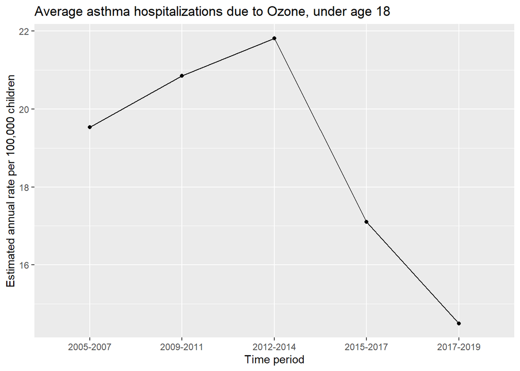

```r
#Linear plot for indicator by time:
ggplot(averaged_data_12_2, aes(x = Period, y = Value, group = 1)) +
  geom_point() +
  geom_line() +
  labs(title = "Average asthma hospitalizations due to Ozone, under age 18",
       x = "Time period",
       y = "Estimated annual rate per 100,000 children")
```

Average asthma hospitalizations due to Ozone fell from 19.53333 per 100,000 children in 2005-2007 to 14.50000 per 100,000 children in 2017-2019. It tells us about potential increase of air quality.

## 13. Boiler Emissions - Total PM2.5 Emissions

```r
#Table with values of indicator:
averaged_data_13
```

```
##   Period    Value
## 1   2013 1.660417
## 2   2015 1.087500
```

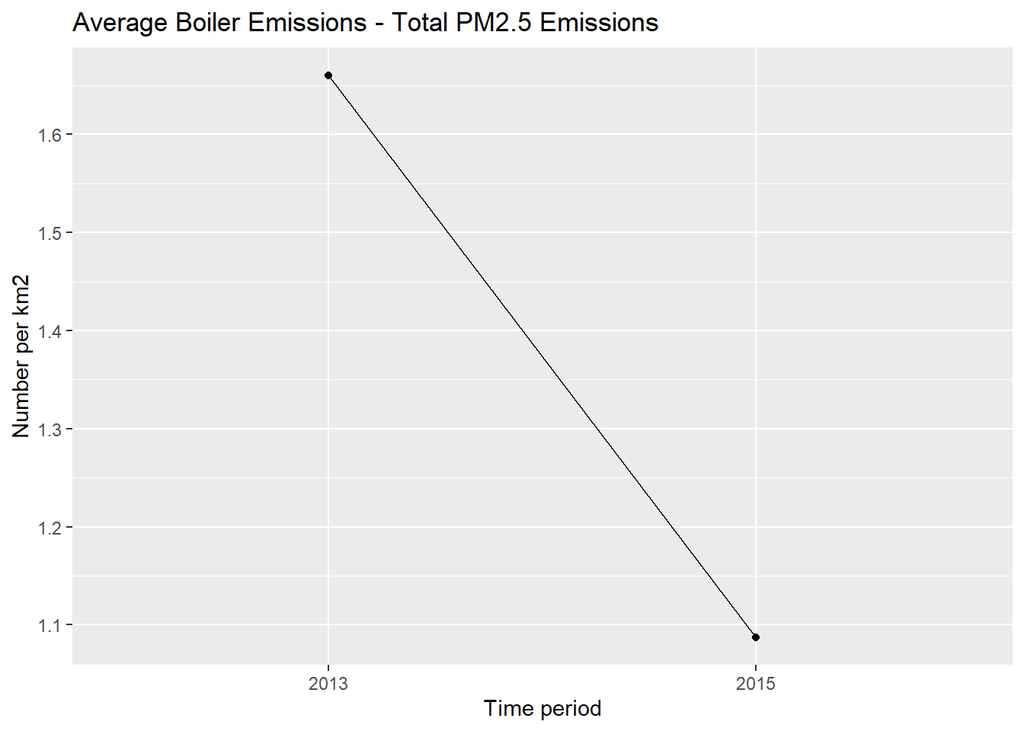

```r
#Linear plot for indicator by time:
ggplot(averaged_data_13, aes(x = Period, y = Value, group = 1)) +
  geom_point() +
  geom_line() +
  labs(title = "Average Boiler Emissions - Total PM2.5 Emissions",
       x = "Time period",
       y = "Number per km2")
```

Average Boiler Emissions - Total PM2.5 Emissions fell from 1.660417 per km2 in 2013 to 1.087500 per km2 in 2015. It tells us about potential increase of air quality.

## 14. Cardiac and respiratory deaths due to Ozone

```r
#Table with values of indicator:
averaged_data_14
```

```
##      Period    Value
## 1 2005-2007 5.085417
## 2 2009-2011 4.872917
## 3 2012-2014 5.135417
## 4 2015-2017 4.887500
## 5 2017-2019 4.854167
```

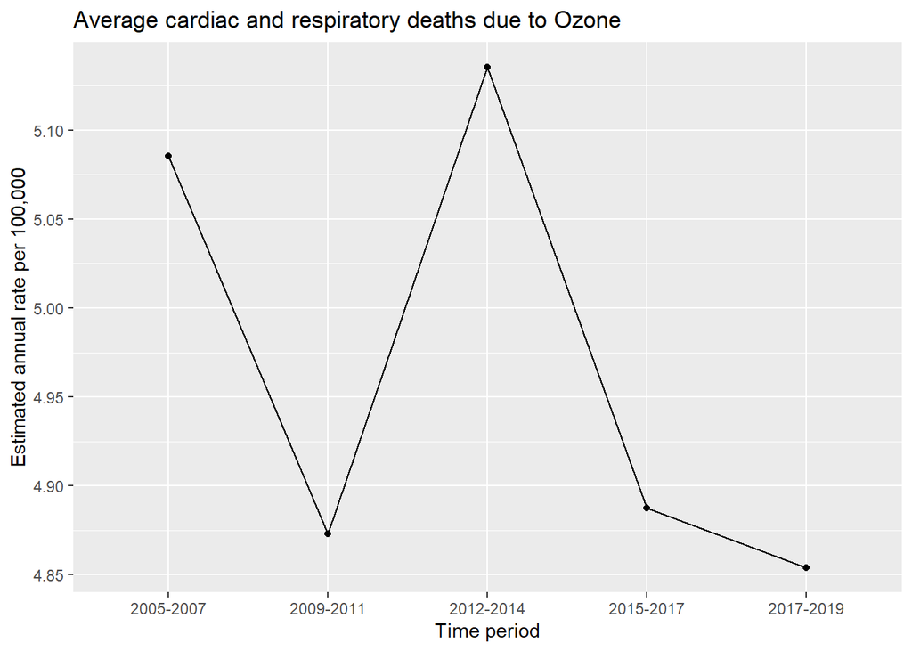

```r
#Linear plot for indicator by time:
ggplot(averaged_data_14, aes(x = Period, y = Value, group = 1)) +
  geom_point() +
  geom_line() +
  labs(title = "Average cardiac and respiratory deaths due to Ozone",
       x = "Time period",
       y = "Estimated annual rate per 100,000")
```

Average cardiac and respiratory deaths due to Ozone fell from 5.085417 per 100,000 in 2005-2007 to 4.854167 per 100,000 in 2017-2019. It tells us about potential increase of air quality.

## 15. Deaths due to PM2.5

```r
#Table with values of indicator:
averaged_data_15
```

```
##      Period    Value
## 1 2005-2007 66.90833
## 2 2009-2011 49.25833
## 3 2012-2014 41.74792
## 4 2015-2017 38.55625
## 5 2017-2019 33.91667
```

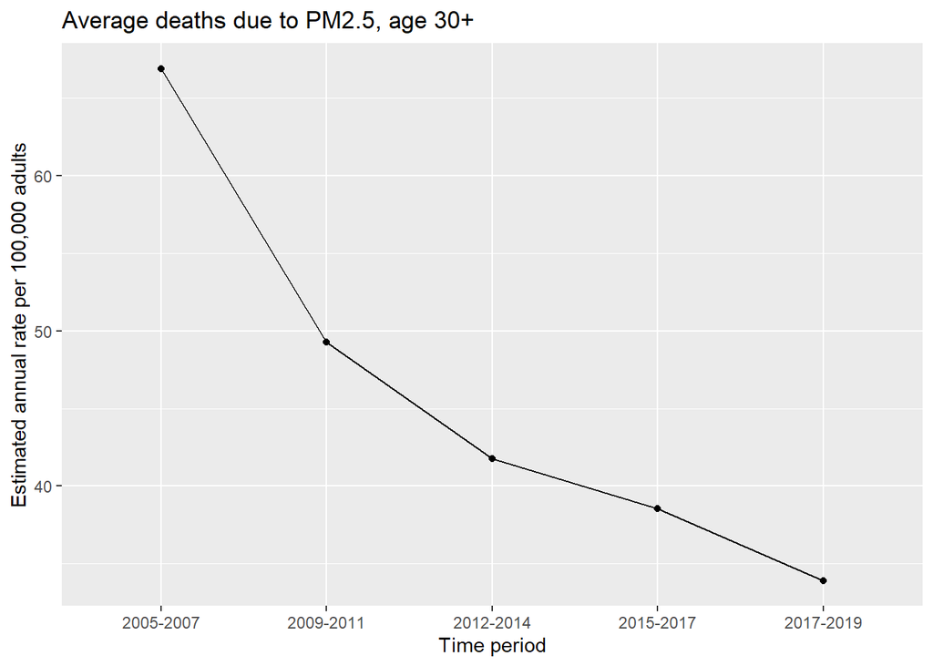

```r
#Linear plot for indicator by time:
ggplot(averaged_data_15, aes(x = Period, y = Value, group = 1)) +
  geom_point() +
  geom_line() +
  labs(title = "Average deaths due to PM2.5, age 30+",
       x = "Time period",
       y = "Estimated annual rate per 100,000 adults")
```

Average deaths due to PM2.5 for people older than 30 years fell from 66.90833 per 100,000 adults in 2005-2007 to 33.91667 per 100,000 adults in 2017-2019. It tells us about potential increase of air quality.

## 16. Nitrogen dioxide (NO2)

```r
#Table with values of indicator:
averaged_data_16$Period <- gsub("Annual Average ", "", averaged_data_16$Period)
averaged_data_16
```

```
##    Period    Value
## 1    2009 25.75390
## 2    2010 23.76383
## 3    2011 24.17376
## 4    2012 22.05745
## 5    2013 21.31986
## 6    2014 21.01560
## 7    2015 20.36028
## 8    2016 19.47660
## 9    2017 19.69149
## 10   2018 18.82695
## 11   2019 17.32553
## 12   2020 16.82057
## 13   2021 17.00426
## 14   2022 16.05461
```

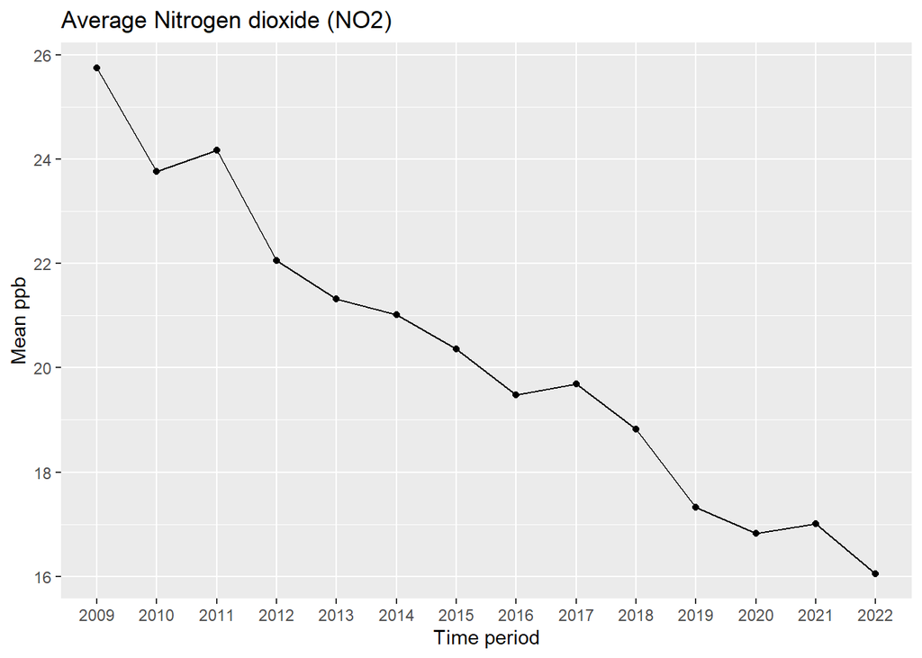

```r
#Linear plot for indicator by time:
ggplot(averaged_data_16, aes(x = Period, y = Value, group = 1)) +
  geom_point() +
  geom_line() +
  labs(title = "Average Nitrogen dioxide (NO2)",
       x = "Time period",
       y = "Mean ppb")
```

Average Nitrogen dioxide (NO2) fell from 25.75390 ppb in 2009 to 16.05461 ppb in 2022. It tells us about potential increase of air quality.

## 17. Outdoor Air Toxics - Formaldehyde

```r
#Table with values of indicator:
averaged_data_17
```

```
##   Period    Value
## 1   2005 3.195833
## 2   2011 2.160748
## 3   2014 1.537500
```

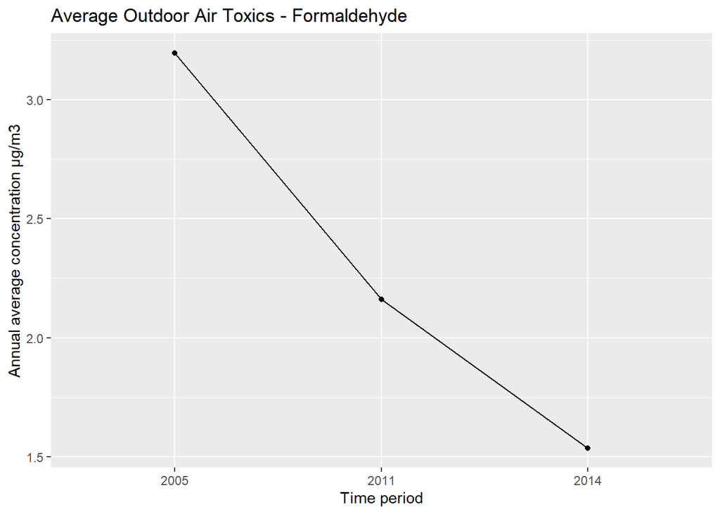

```r
#Linear plot for indicator by time:
ggplot(averaged_data_17, aes(x = Period, y = Value, group = 1)) +
  geom_point() +
  geom_line() +
  labs(title = "Average Outdoor Air Toxics - Formaldehyde",
       x = "Time period",
       y = "Annual average concentration µg/m3")
```

Average Outdoor Air Toxics - Formaldehyde fell from 3.195833 µg/m3 in 2005 to 1.537500 µg/m3 in 2014. It tells us about potential increase of air quality.

## 18. Respiratory hospitalizations due to PM2.5, age 20+

```r
#Table with values of indicator:
averaged_data_18
```

```
##      Period    Value
## 1 2005-2007 20.72917
## 2 2009-2011 14.44375
## 3 2012-2014 12.09583
## 4 2015-2017 12.20000
## 5 2017-2019  7.43750
```

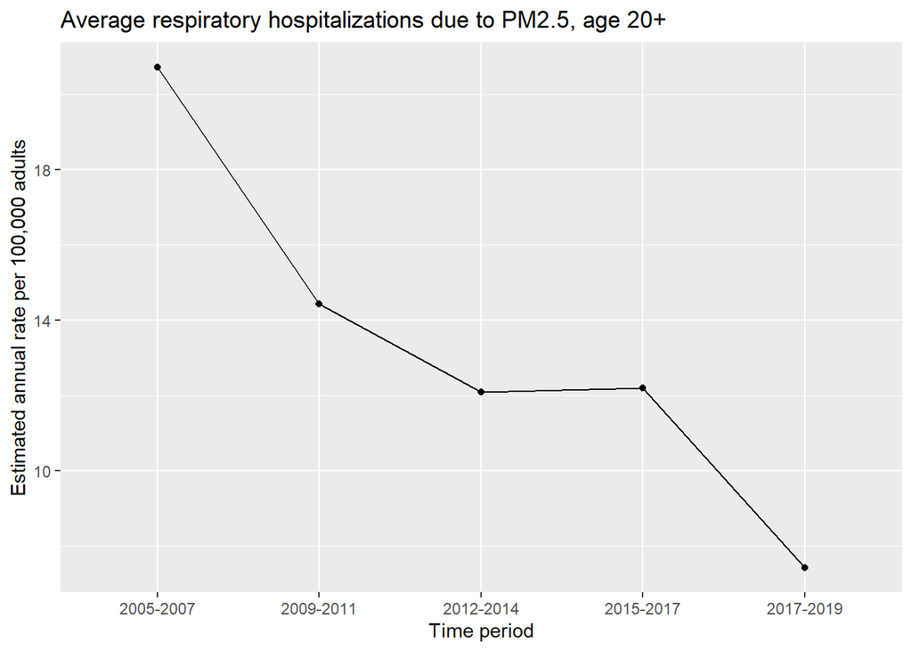

```r
#Linear plot for indicator by time:
ggplot(averaged_data_18, aes(x = Period, y = Value, group = 1)) +
  geom_point() +
  geom_line() +
  labs(title = "Average respiratory hospitalizations due to PM2.5, age 20+",
       x = "Time period",
       y = "Estimated annual rate per 100,000 adults")
```

Average respiratory hospitalizations due to PM2.5 for people older than 20 years fell from 20.72917 per 100,000 adults in 2005-2007 to 7.43750 per 100,000 adults in 2017-2019. It tells us about potential increase of air quality.

## Conclusion

Almost all indicators of air quality in New York city were improved during the analyzed period. Some deterioration is observed in miles traveled by cars. However, increase in fuel efficiency of vehicles allowed to avoid growth of emissions. Some increase is also observed in average Ozone (O3). However, in general, air quality grew.